# OMICsPCA: An R package for quantitative integration and analysis of multiple omics assays from heterogeneous samples

#### **3.10.1 Validation of clusters**

```r
#### Using silhouette index
# calculating the distance matrix
library(cluster)
```

```r
dist <- daisy(data)

sil = silhouette(clusters$cluster$cluster,dist)

# RStudio sometimes does not display silhouette plots
#correctly. So sometimes, it is required to plot in separate
#window.

#grDevices::windows()
#plot(sil)
```

#### **3.10.2 Identification of misclassified points**

```r
# Identification of misclassified data points
# silhouette width of misclassified points are negative
misclassified <- which(sil[,3] < 0)

head(sil[misclassified,])
```

```
##      cluster neighbor   sil_width
## [1,]       0        1 -0.04242416
## [2,]       0        2 -0.01904871
## [3,]       0        2 -0.03108728
## [4,]       0        1 -0.07175940
## [5,]       0        1 -0.12576245
## [6,]       0        2 -0.06284128
```

```r
data[misclassified[3:7],]
```

```
##                                         Dim.1    Dim.2     Dim.3      Dim.4
## ENST00000552049.1;ENST00000546756.1 1.7202516 0.313471 0.9095707 -1.3984965
## ENST00000219240.4                   5.8439693 3.244593 0.7721712  0.9258375
## ENST00000295500.4                   5.1304465 1.081242 3.0519371 -2.8619556
## ENST00000601209.1;ENST00000396819.3 0.5545207 1.906045 0.1843264  0.9446085
## ENST00000456580.2                   5.1492365 3.350805 0.6372836  0.6221167
```

We may reorganize the misclassified points into appropriate clusters.

#### **3.10.3 Exploration of clusters**

let’s explore the clusters more

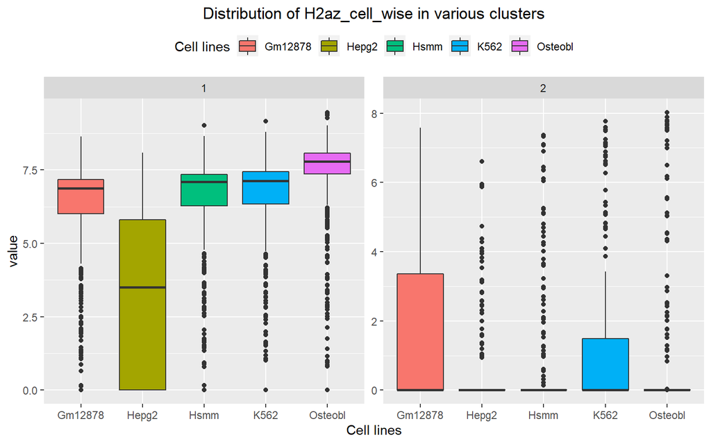

```r
bp <- cluster_boxplot(name = multi_assay,
Assay = "H2az", clusterobject = clustered_data,
clustercolumn = 5)


bp <- bp+xlab("Cell lines") + ylab(
"value")+ggtitle(
"Distribution of H2az_cell_wise in various clusters")+theme(
plot.title=element_text(hjust=0.5),
legend.position = "top")+guides(
fill=guide_legend("Cell lines"))

bp
```

The overall distribution of H2az is significantly different in the two clusters, implying a good clustering by density based. This process may be applied to other factors or other clustering methods.

## **4 Summary**

Most of the multi-omics data integration algorithms are focused on 2 applications:

1. use of integrated data for class prediction (e.g. identification of diseased individuals) and
2. analysis of the source of variation across samples and individuals.

However, such approaches do not suffice to other potential applications including quantitative representation of the combined effect of multiple data modalities, clustering of individuals on the basis of combined epigenetic state etc. We propose here a new tool OMICsPCA, designed for integrative analysis of multi-omics data including the ones mentioned above.

Integration of multi-omics data involves 2 major tasks:

1. analysis of the source of variation among the samples of a data modality and
2. calculation of the combined effect of multiple data modalities on the individuals.

We used a **3 step process** to analyse the variation among the samples of each data modality. **First**, we used **descriptor()** and **chart_correlation()** to get an initial clue about the overall nature of the samples. **Second**, we used **integrate_variables()**, **analyse_variables()** and **analyse_individuals()** to dissect the variation among the samples of a modality, as well as the individuals in a group-wise manner. **Third**, we used density analysis to study the internal structure of the data distribution which in turn used to identify the “discriminatory data modalities” or assays that show different density structures in different groups of individuals. These 3 step process is used to study the difference between the groups of individuals and to select the similar samples corresponding to a data modality.

In the second task, we linearly combined all the similar samples corresponding to the selected factors (these may be the discriminatory factors) using Principal Component Analysis (PCA). Each of the Principal components represents the combined state of various data modalities across multiple samples. We used these combined metrices to identify similar individuals (TSSs) by various clustering methods.

OMICsPCA overcomes the limitations of the existing tools and has a good potential to be used as an multipurpose data integration and analysis tool.

## **5 References**

1. Huang YT. Integrative modeling of multiple genomic data from different types of genetic association studies. Biostatistics. 2014 Oct;15(4):587-602. PubMed PMID: 24705142.
2. He X, Fuller CK, Song Y, Meng Q, Zhang B, Yang X, et al. Sherlock: detecting gene-disease associations by matching patterns of expression QTL and GWAS. American journal of human genetics. 2013 May 2;92(5):667-80. PubMed PMID: 23643380. Pubmed Central PMCID: 3644637.
3. Xiong Q, Ancona N, Hauser ER, Mukherjee S, Furey TS. Integrating genetic and gene expression evidence into genome-wide association analysis of gene sets. Genome research. 2012 Feb;22(2): 386-97. PubMed PMID: 21940837. Pubmed Central PMCID: 3266045.
4. Ha M, Hong S. Gene-regulatory interactions in embryonic stem cells represent cell-type specific gene regulatory programs. Nucleic acids research. 2017 Oct 13;45(18):10428-35. PubMed PMID: 28977540. Pubmed Central PMCID: 5737473.
5. Chen L, Ge B, Casale FP, Vasquez L, Kwan T, Garrido-Martin D, et al. Genetic Drivers of Epigenetic and Transcriptional Variation in Human Immune Cells. Cell. 2016 Nov 17;167(5):1398-414 e24. PubMed PMID: 27863251. Pubmed Central PMCID: 5119954.
6. Consortium GT. Human genomics. The Genotype-Tissue Expression (GTEx) pilot analysis: multitissue gene regulation in humans. Science. 2015 May 8;348(6235):648-60. PubMed PMID: 25954001. Pubmed Central PMCID: 4547484.
7. Lanckriet GR, De Bie T, Cristianini N, Jordan MI, Noble WS. A statistical framework for genomic data fusion. Bioinformatics. 2004 Nov 1;20(16):2626-35. PubMed PMID: 15130933.
8. Wang B, Mezlini AM, Demir F, Fiume M, Tu Z, Brudno M, et al. Similarity network fusion for aggregating data types on a genomic scale. Nature methods. 2014 Mar;11(3):333-7. PubMed PMID: 24464287.
9. Argelaguet R, Velten B, Arnol D, Dietrich S, Zenz T, Marioni JC, et al. Multi-Omics Factor Analysis-a framework for unsupervised integration of multi-omics data sets. Molecular systems biology. 2018 Jun 20;14(6):e8124. PubMed PMID: 29925568. Pubmed Central PMCID: 6010767.